# Physicians shortage and medical education in Poland

dr Katarzyna Strzała-Osuch, prof. PSW, dr hab. Tomasz Plata-Przechlewski, prof. PSW, mgr Julia Osuch

Powiślańska Szkoła Wyższa/2023

# Background

There is a confirmed relationship between population health and the number (and quality) of medial staff

Staff shortages in the health care (HC) system are currently a serious barrier to the implementation of proper medical care in Poland and Europe

Staff shortages in HC can be attributed to several factors: **aging population**, **personel burnout**, but also:

- improper management of human resources,
- failure to adjust the **employment structure** to health needs,
- a defective education system based on public universities monopoly
- HC system underfunding

There are also common public opinions (aka myths) on this problem:

- Staff shortages are particularly acute in Poland
- Staff shortages are caused by mass abroad migration (of doctors)
- Number of medical staff is decreasing
- To have more doctors an enrollment quota should go up, but only at public universities which guarantee high quality

# Objectives of this study

Comparison of the number of physicians and medical graduates in Poland and European Union countries.

Development of several simple scenarios for the demand for doctors in Poland in the years 2023–2048

Establish the basic facts and debunk public myths

# Material and method

Data on the number of doctors/medical graduates come from Eurostat (tables `hlth_rs_phys`, `hlth_rs_grd` and `hlth_rs_wkmg`).

Population data and population projections are also from Eurostat (table `demo_pjan` and `proj_23np`).

Data from the Local Data Bank of the [Polish] Central Statistical Office (table OCHR_2612_CREL_20220612185524) were also used. (cf https://bdl.stat.gov.pl/bdl/start)

Data on the number of graduates who passed the Medical Final Exam were downloaded from the website of the Center for Medical Examinations (*Centrum Egzaminów Medycznych*)

(cf https://www.cem.edu.pl/aktualnosci/lep/lep_stat3.php.)

Additionally selected information contained in reports and scientific publications on the subject was used.

# Number of doctors in EU

We use [number of] **people per 1 physician** rate (last reported year; 2017 for PL)

EU member states were divided into two groups:

- **new member states** (NEU), ie. Czech Rep., Estonia, Lithuania, Latvia, Poland, Slovakia, Slovenia, Hungary, Bulgaria, Romania and Croatia.
- **old member states** (OEU), Austria, Belgium, Denmark, Finland, France, Germany, Greece, Ireland, Italy, Netherlands, Portugal, Spain, Sweden.

Cyprus, Malta and Luxembourg were omitted.

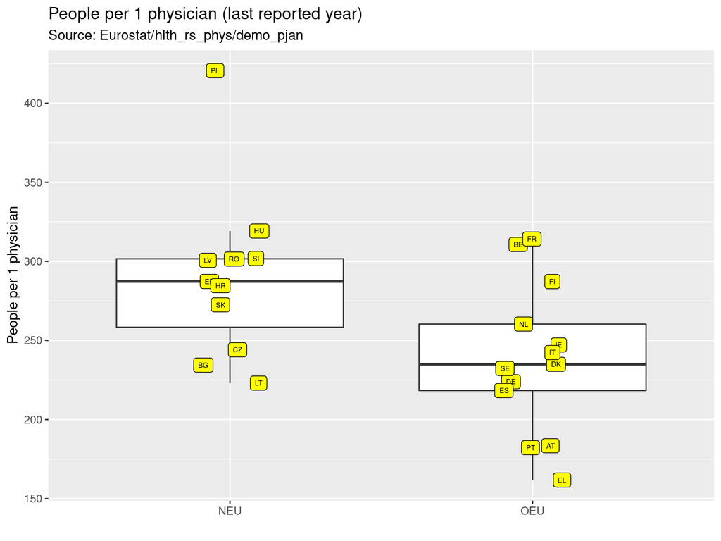

As expected in new members the vale of the indicator is on the average (median) higher (287.3 vs 234.9)

Poland has the worst value of the rate (420.6), which is 146.4% of the median in the group of new EU countries and as much as 179.0% in the group of old EU members.

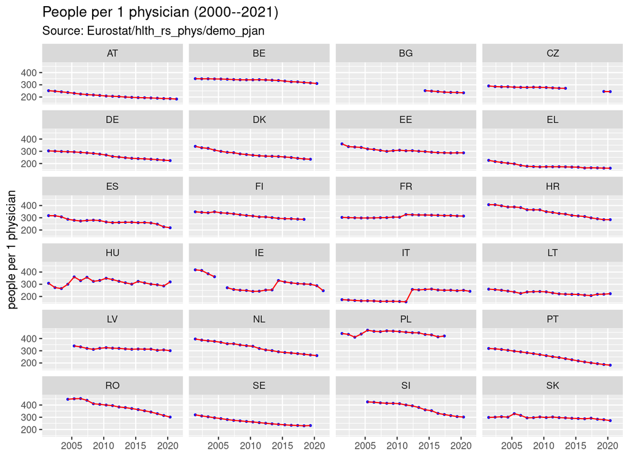

Median of the last reported value (for the entire analyzed group of EU countries) is 253.7.

The median of the average change in the reporting period is -3.52. (in half of the countries, the value of the indicator drops not less than -3.52 )

The value of the indicator for Poland is 420.6 and is 65.8% higher than the median value;

The average change in the reporting period in Poland is -1.29 (From year to year, there is 1.3 less people per one doctor); which is 36.6% of the median for the analyzed group of countries (-3.52).

# Elderly people per 1 physician

Due to the aging of the population it is worth analyzing the ratio of the number of **elderly people per 1 physician** (ie. people aged 65+ per 1 physician).

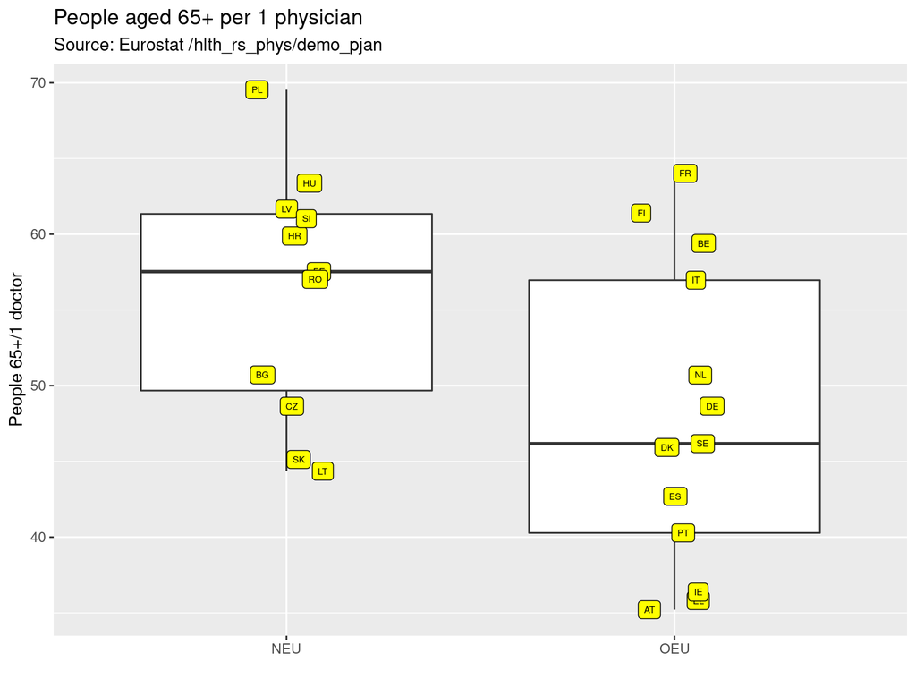

On the average, new EU countries have higher rates (median equal to 57.5 than old ones (46.2)

Poland has again the worst rate value (69.5)

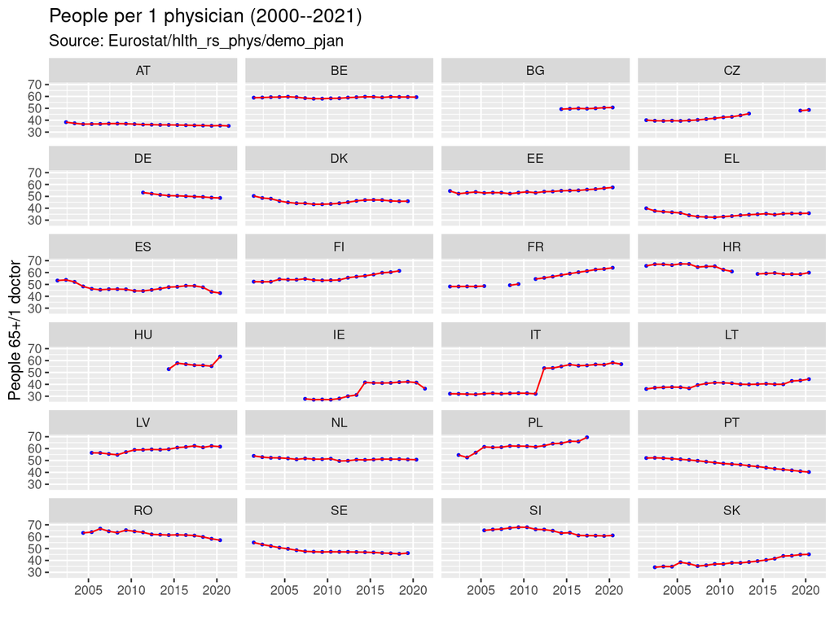

Note that the data is severely incomplete.

The median of the last reported value is 50.7.

The median of the average change in the reporting period is 0.091. (in half of the countries, the rate value increases on average no more than 0.1 )

The value of the indicator for Poland is 69.5 and is 37.2% higher than the median value;

The average change in the reporting period is 1.0 and is 996.2% higher than the median

# Graduates of medical studies

Medical graduates are future doctors. Therefore, the **population per 1 graduate** rate determines the size of the stream supplying the HC system with new staff.

We compare new and old EU member states for 2017 vs 2002

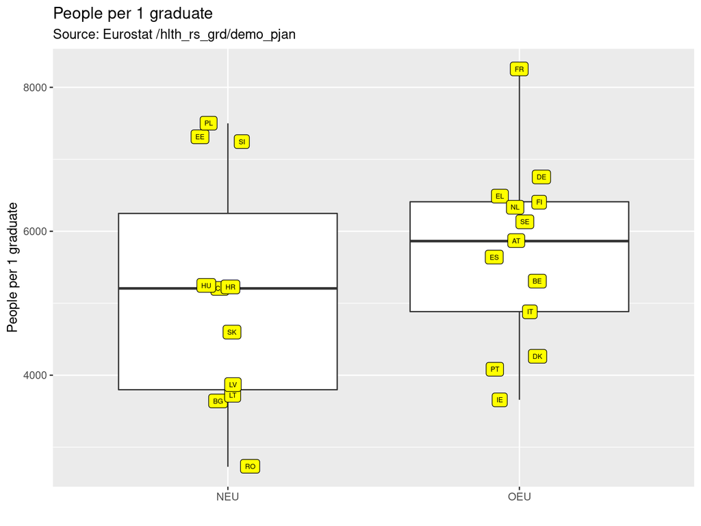

On the average, there were more medical graduates in the new EU countries. Poland is next to last (again), but many countries with a better reputation for HC have relatively high values (Germany, Sweden, Finland) as well.

The median population per graduate ratio in the group of new EU members is 5206 (Poland 7499 or 144.04%).

In the last reported year, there were 5064 graduates in Poland. To achieve the average for new EU members it would be necessary to educate 7294, i.e. about 2230 more (increase by 44.0% ). Pretty formidable task.

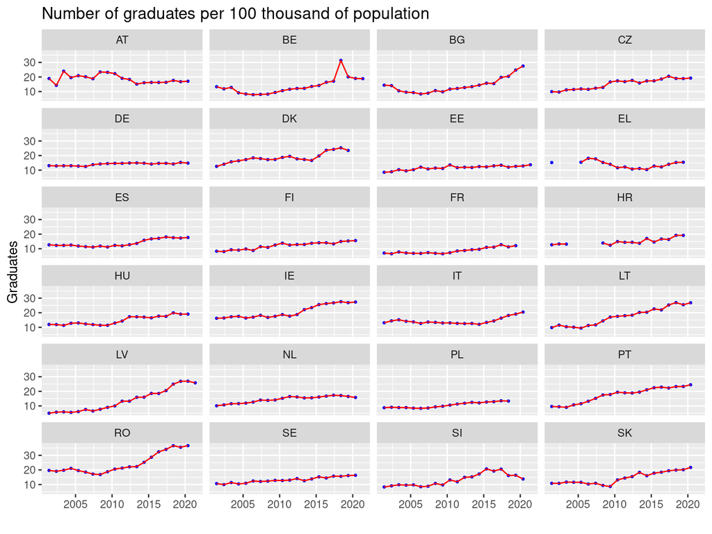

There is constant increase in the number of graduates in Poland

# Scenarios of demand for physicians in Poland

Scenarios are based on population projection from Eurostat (table `proj_23np`.)

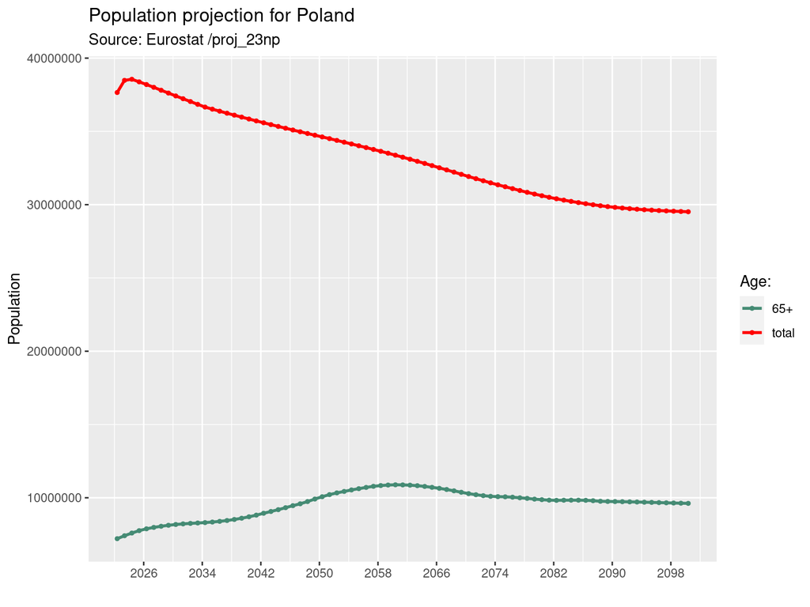

The number of people aged 65+ in Poland will systematically grow until 2062, reaching over 10 million.

The share of people aged 65+in Europe will increase. The median for the analyzed group of countries in 2023 will be 20.4 and in 2048 it will be 27.4

In 2017, the total population of Poland was 37972964, population aged 65+ was 6278376 (16.53%)

In 2048 the total population of Poland will be 34855698, while population aged 65+ 9740966 (27.95%)

# Increase in the number of doctors in the HC system

The average increase in the number of doctors in Poland was assessed using the Local Data Bank of the Central Statistical Office, which is more up-to-date than the Eurostat data.

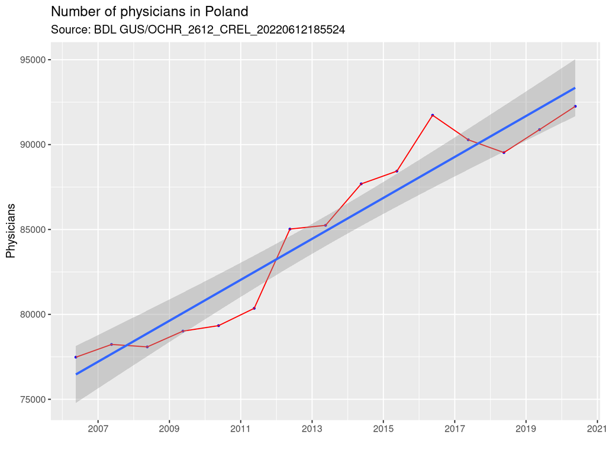

Steady increase in the analyzed period is observed. The approximation with linear trend showed that, the average annual increase in the number of doctors was 1206.0.

# Demand scenarios

The number of doctors is estimated, taking into account **the population projection** under the assumption that Poland is catching up with the rest of the EU.

Specifically, five scenarios were considered, assuming that in 2048 (i.e. in 25 years):

1. The per capita rate [of doctors] in the 65+ group will be equal to the average in the group of new EU members, adjusted by the average annual change
2. The per capita rate [of doctors] in the 65+ group will be equal to the average in the whole EU, adjusted by the average annual change
3. The total per capita rate [of doctors] will be equal to the average in the group of new EU members, adjusted by the average annual change
4. The total per capita rate [of doctors] will be equal to the average in the whole EU, adjusted by the average annual change
5. The per capita rate [of doctors] in the 65+ group will be equal to the value for PL for 2017 (it will not deteriorate), adjusted by the average annual change

Of course, this is a very simplified assumption and it boils down to determining what will happen if the observed trends do not change.

The rapid aging of the population justifies the use of the population 65+/doctor rate, not the total population rate.

Scenarios 1–5 and a linear trend line assuming an average annual increase in physicians in 2018–2048 equal to the one observed in years 2006–2020 (i.e. 1206.0 doctors per year) are presented at the chart below

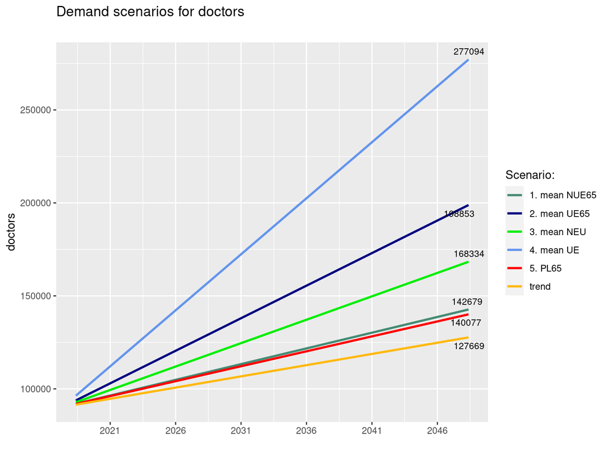

None of the scenarios will be implemented assuming that the current rate of growth in the number of doctors is maintained

Even the least ambitious scenario 5 assuming only no deterioration of the 65+ population ratio per doctor will not be implemented either.

The table shows the additional number of doctors (compared to the number resulting from the linear trend, i.e. 127669) necessary to implement in the year 2048 this specific scenario.

The last column doctors/year is the average annual increase in the number of doctors necessary to implement a specific scenario.

For example, in scenario 3 in the year 2048 there should be 40665 more doctors in the system, or 1627 more per year.

| Scenario | doctors | doctors/year |
| --- | --- | --- |
| 1. średnia NEU65 | 15010 | 600 |
| 2. średnia UE65 | 71184 | 2847 |
| 3. średnia NEU | 40665 | 1627 |
| 4. średnia UE | 149425 | 5977 |
| 5. PL65 | 12408 | 496 |

# Where will the extra doctors come from?

Potentially two sources:

- from the national higher education system, and
- by recruiting doctors/graduates educated abroad.

# Number of graduates entering the profession

There is no data on the number of graduates of medical faculties of Polish medical schools, but the Center for Medical Examinations (CEM) publishes data on the results of Medical Final Examinations.

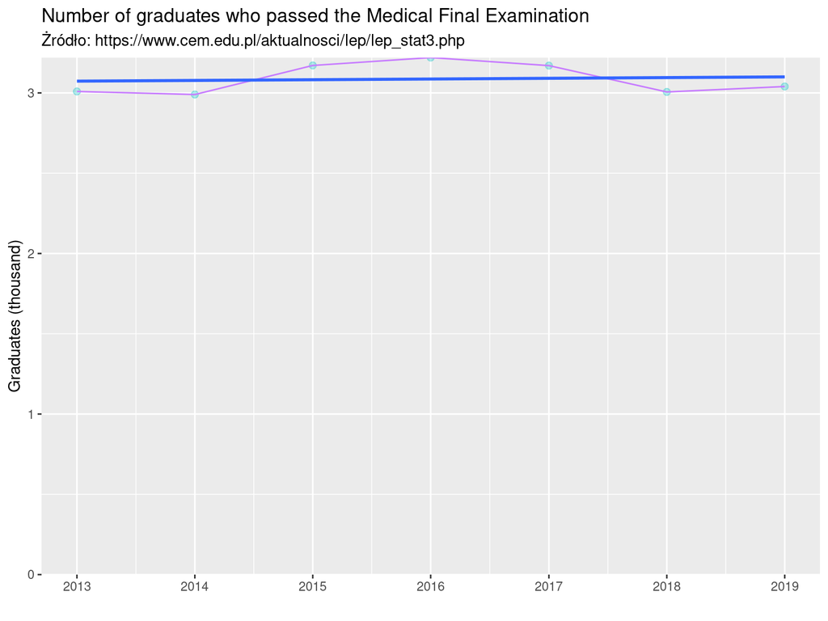

Practically no increase is observed in the analyzed period (on the average, there are extra 0.0044286 graduates per year.)

Conclusion1: with the current system of education, there is no chance for a greater influx of doctors to the system.

Conclusion2: the low dynamics of the number of graduates entering the profession contradicts the high dynamics of graduates (according to Eurostat) We have no explanation to that

# Doctors educated abroad

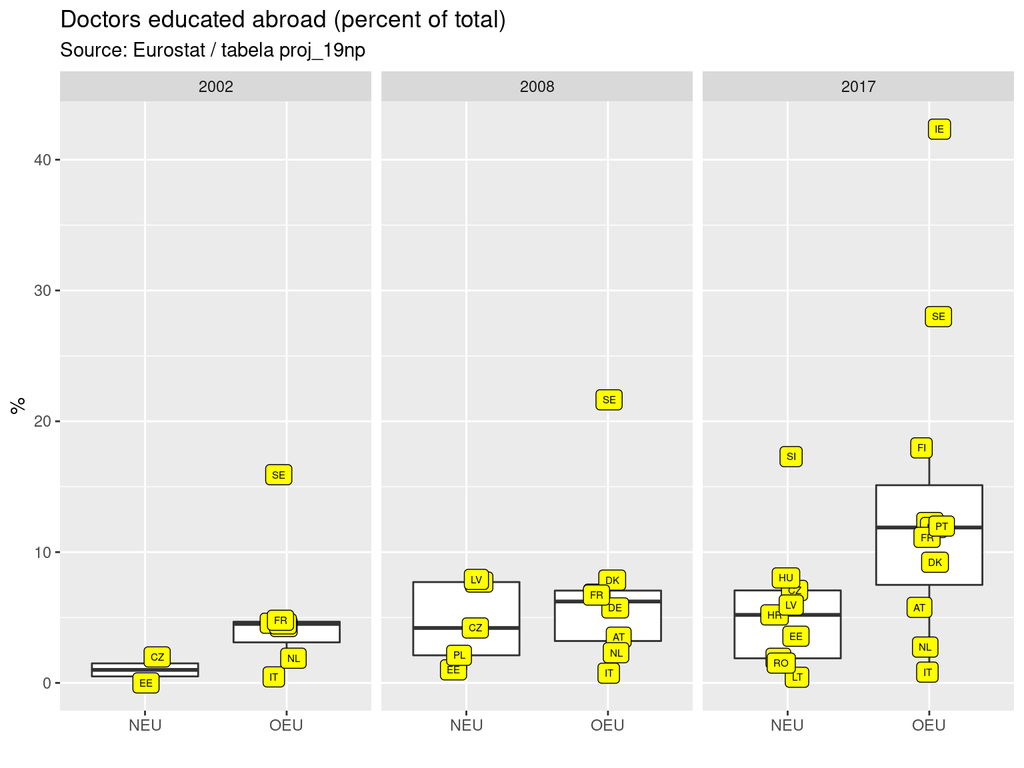

Or mean averages for EU new/old member states.

| Group | 2002 | 2008 | 2017 |
| --- | --- | --- | --- |
| NEU | 0.995000 | 4.58600 | 5.661111 |
| OEU | 5.205714 | 6.91125 | 14.010000 |

In the new EU countries, the share of immigrant doctors is marginal;

In the new EU countries, this share increases slightly (in 15 years by less than 5%, practically from zero)

Seems migrants are not silver-bullet.